# SyntenyViz Analysis Workflow

```r
library(SyntenyViz)
```

The course below demonstrates a standard analysis pipeline with the `SyntenyViz` R package.

# 1 For the inpatients

Quick and minimum steps to get start a synteney conservation anaysis with SyntenyViz

- Define an investigation range We need to firstly define an investigation range to cover the target range in gene coordinate. We will use a mouse dipeptidyl dipeptidase 4 gene (DPP4-mm) in this example, where DPP4-mm locates at chromosome number 2 between 62,330,073-62,412,231 bp.

```r
# orgm is a handle for organism
orgmName <- "Mmusculus"
# mycoords.list is the investigation range handler
mycoords <- "2:6.0e7:6.5e7"
```

- Convert `mycoords.list` into a GRange object

```r
mycoords.gr <- SyntenyViz::coordFormat (mycoords.list = mycoords)
```

It is always a good habit to double check the input, so

```r
mycoords.gr
```

```
#> GRanges object with 1 range and 0 metadata columns:
#>       seqnames            ranges strand
#>          <Rle>         <IRanges>  <Rle>
#>   [1]     chr2 60000000-65000000      *
#>   -------
#>   seqinfo: 1 sequence from an unspecified genome; no seqlengths
```

- Construct a single synteny graph

```r
synvizPlotData(mycoords.gr, orgmName)
```

```
#> $itrack
#> Ideogram track 'Mmusculus chromosome chr2' for chromosome 2 of the mm10 genome
#>
#> $gtrack
#> Genome axis 'Axis'
#>
#> $atrack
#> AnnotationTrack 'Mmusculus'
#> | genome: mm10
#> | active chromosome: chr2
#> | annotation features: 22
```

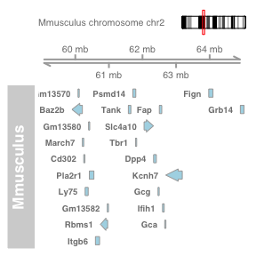

Synteny of Mouse DPP4

```r
synvizPlot(mycoords.gr, orgmName)
```

- Construct a multi synteny graph

Then construct a multiple synteny query

```r
orgmsList <- orgmsCollection.init (orgmsList)
orgmsList <- orgmsAdd (orgm.1, orgmTxDB, mycoords.list.1, orgmsList)
orgmsList <- orgmsAdd (orgm.2, orgmTxDB, mycoords.list.2, orgmsList)
orgmsList <- orgmsAdd (orgm.3, orgmTxDB, mycoords.list.3, orgmsList)
```

Now, construct a comparative multi-synteny graph

[output not shown]

[figure not shown]

```r
multiplot <- multisynvizPlots(orgmsList)
```

```r
multiplot
```

[output not shown]

# 2 The Nitty Gritty of Synteny Analysis

## 2.1 Construct A Search Query

A search query includes the information of target organism(s) and the region(s) of interests. A typical work flow starts by locating the gene of interests. In this example, we will use a protease gene dipeptidyl dipeptidase-4 (DPP4) as a target.

### 2.1.1 DPP4 background

DPP4 is also known by a few other names including adenosine deaminase complexing protein 2 (ADCP2) and CD26. Human DPP4 gene encodes a 766 amino acids protein. DPP4 proteins dimmerise and then possesses potent rare post-proline hydrolytic activity *in situ*. In clinics, DPP4 has been demonstrated to involve in many important physiobiological functions including homeostasis, adaptive immune responses and numerous cancer biology. Due to its degradation property towards GLP and GIP, pharmacologically, DPP4 inhibitors have been prescribed as an alternative treatment to type 2 diabetics.

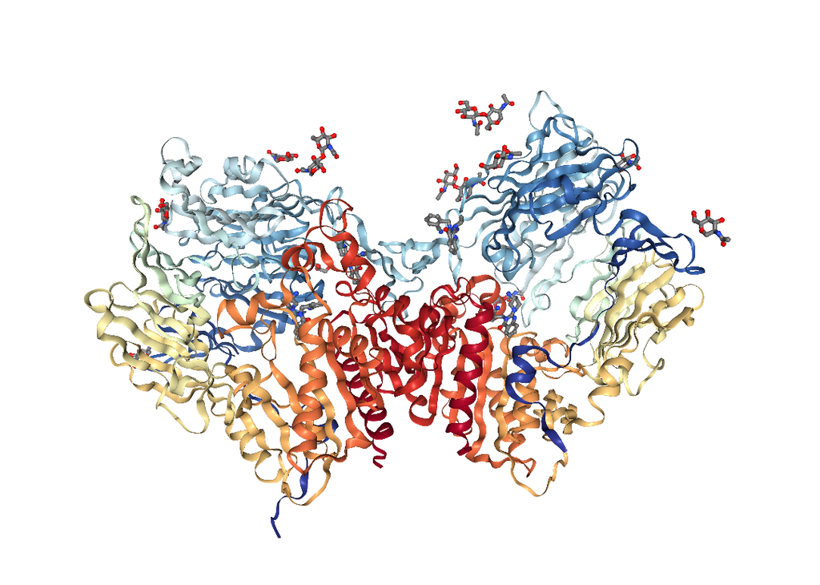

DPP4 protein in dimmer form

```r
knitr::include_graphics('images/DPP4.png')
```

### 2.1.2 Locate DPP4 gene and define the investigation ranges

#### 2.1.2.1 Locate gene (e.g. DPP4 gene)

To locate DPP4 gene, both [Ensemble](http://www.ensembl.org/index.html) and [GeneBank](https://www.ncbi.nlm.nih.gov/gene) are good resources for this purpose.

Let’s say we want to find the location of **human DPP4 gene** location.

- [Ensemble query](https://www.ensembl.org/Homo_sapiens/Gene/Summary?g=ENSG00000197635;r=2:161992245-162074215)
- [GeneBank query](https://www.ncbi.nlm.nih.gov/gene/1803)

indicate human DPP4 gene is located on **chromosome 2** between **161992245-162074215 bp**.

#### 2.1.2.2 Define the investigation ranges

Given that human DPP4 related genes are clustered closely and we only interested in the synteny of DPP4 gene in this case, therefore, **0.25e7 bp** on either side of DPP4 gene seems a good fit (i.e. **15.95e7-16.45e7** bp will be the investigation range).

Hence, we can now define the investigation range as

```r
# orgm is a handle for organism
orgm <- "Hsapiens"
# mycoords.list is the investigation range handler
mycoords.list <- "2:15.95e7:16.45e7"
```

then we need to convert `mycoords.list` into a squence coordinate in GRange object, here we can call a convertion function

```r
# Return mycoords.gr as a GRange object
mycoords.gr <- coordFormat (mycoords.list = mycoords.list)
```